# Evidencia 1 Parte 2

Julieta Arteaga, Guillermo Villegas, Gabriel Melendez, Adara Pulido, Gustavo Ortiz

2023-04-26

Parte 1.

Actualmente a nivel mundial se han acumulado 764,474,387 de casos de Covid 19, de los cuales casi siete millones fallecieron, esto según datos de la Organización Mundial de la Salud (WHO, 2023). Para conocer información de la epidemia de México y entidades estatales y municipales se consultó el portal del CONACYT dedicado a datos sobre los contagios de coronvarius. Hasta el 29 de abril de 2023 se contabilizaron 14,363 casos activos en toda la república, 340 solo en Jalisco de los cuales 72 residen en Zapopan. México ha sumado 7,587,172 contagios y 333,895 defunciones (Conacyt, 2023) El SARS-CoV-2 evolucionó en los años transcurridos de la pandemia en diferentes variantes, mutaciones, linajes, sublinajes y recombinaciones. En específico, las variantes, que se definen como como un genoma viral que puede incluir más de una mutación no representan mayor problema hasta que logran cambiar los atributos y características de la infección. Por esto mismo, el HHS de E.E.U.U. creó el Grupo Interagencial por el SARS-CoV- 2 (SIG), un grupo compuesto de agentes de diferentes insituciones gubernamentales del país con el fin de coordinar sus esfuerzos para la clasificación de variantes emergentes y analizar sus implicaciones con las vacunas, tratamientos y diagnósticos. El SIG cuenta con 4 clasificaciones de variantes: de interés, preocupación, gran consecuencia y de monitoreo. El 29 de diciembre de 2020, fueron declaradas las tres primeras variantes, Alpha, Beta y Gamma. De primera instancia se consideraban variantes de preocupación, actualmente están clasificadas como variantes bajo monitoreo (Centro para el Control y la Prevención de Enfermedades, 2023). Las siguientes en ser identificadas fueron las variantes Delta, Epsilon, Eta, Iota, Kappa, ómicron, Zeta y Mu. Al día de hoy solo el ómicron recibe la clasificación de variante de preocupación, todas las demas están solo bajo monitoreo. El gobierno de México realiza informes sobre variantes de Covid-19 detectadas en el país de manera semanal, la información se puede consultar en los reportes de vigilancia genómica del virus SARS-CoV-2 en Méixco que realiza la Secretaríad de Salud y la Dirección Genral de Epidemiología.

#Imagina que te encuentras en una situación similar a la de Li Wenliang, médico chino que intentó alertar sobre el brote de coronavirus en su país, pero fue detenido por las autoridades y obligado a retractarse, ¿qué harías en su caso? Selecciona un inciso:a) Lo reportas al centro de investigación o la universidad. b) Lo reportas a la prensa. c) Guardas la información. Elige y justifica tu respuesta. Analizando la situación, cualquiera de las dos primeras alternativas son poco efectivas en China donde la población está siendo constantemente vigilada, aparte de esto la c no es opción por simple ética y valores. Si nos encontraramos en la situación de Li Wenliang, recopilaríamos toda la información que se conozca y buscaríamos alguna manera de filtrarla a E.E.U.U. o algún otro país miembro del Consejo de Seguridad de las Naciones Unidas para poner a China en cuarentena y que pueda entrar la OMS a investigarla. Esto lograría con el uso de un VPN y de no ser posible buscaría a un hacker.

Conacyt (29 de abril de 2023). Covid-19 México, información general. Recuperado de https://datos.covid-19.conacyt.mx/

Centro para el Control y la Prevención de Enfermedades (20 de marzo del 2023). Clasificaciones y definiciones de las variantes SARS-CoV-2. Recuperado de https://espanol.cdc.gov/coronavirus/2019-ncov/variants/variant-classifications.html World Health Organization. (24 de abril de 2023). WHO Coronavirus (COVID-19) Dashboard. Recuperado de https://covid19.who.int/.

Parte 2.

1. Obtén las secuencias de las variantes de SARS-CoV-2 desde el NCBI. o el buscador de virus del NCBI

```r
library('seqinr')
library('ggplot2')
library('viridis')
library('plyr')
SARS_SAf_fas <- read.fasta('Copia de sequence (south africa).fasta')
SARS_Ame_fas <- read.fasta('Copia de sequences (America).fasta')
SARS_Bra_fas <- read.fasta('Copia de sequences (brazil).fasta')
SARS_Col_fas <- read.fasta('Copia de sequences (colombia).fasta')
SARS_Fra_fas <- read.fasta('Copia de sequences (france).fasta')
SARS_Ind_fas <- read.fasta('Copia de sequences (india).fasta')
SARS_Ita_fas <- read.fasta('Copia de sequences (italy).fasta')
SARS_Mex_fas <- read.fasta('Copia de sequences (mexico).fasta')
SARS_Peru_fas <- read.fasta('Copia de sequences (peru).fasta')
SARS_Roma_fas <- read.fasta('Copia de sequences (roma).fasta')
SARS_Rus_fas <- read.fasta('Copia de sequences (russia).fasta')
SARS_Spa_fas <- read.fasta('Copia de sequences (spain).fasta')
SARS_UK_fas <- read.fasta('Copia de sequences (uk).fasta')
SARS_Omicron_fas <- read.fasta('Copia de omicron.fasta')
```

2. Calcula la longitud de las secuencias de cada variante.

```r
tamaño <- function(seq){
  return(length(seq))
}


# El tamaño de cada secuencia:
tamaño(SARS_SAf_fas[[1]])
```

```
## [1] 29849
```

```r
tamaño(SARS_Ame_fas[[1]])
```

```
## [1] 29882
```

```r
tamaño(SARS_Bra_fas[[1]])
```

```
## [1] 29858
```

```r
tamaño(SARS_Col_fas[[1]])
```

```
## [1] 29903
```

```r
tamaño(SARS_Fra_fas[[1]])
```

```
## [1] 29903
```

```r
tamaño(SARS_Ind_fas[[1]])
```

```
## [1] 29814
```

```r
tamaño(SARS_Ita_fas[[1]])
```

```
## [1] 29720
```

```r
tamaño(SARS_Mex_fas[[1]])
```

```
## [1] 29409
```

```r
tamaño(SARS_Peru_fas[[1]])
```

```
## [1] 29511
```

```r
tamaño(SARS_Roma_fas[[1]])
```

```
## [1] 322
```

```r
tamaño(SARS_Rus_fas[[1]])
```

```
## [1] 29903
```

```r
tamaño(SARS_Spa_fas[[1]])
```

```
## [1] 29903
```

```r
tamaño(SARS_UK_fas[[1]])
```

```
## [1] 29799
```

```r
tamaño(SARS_Omicron_fas[[1]])
```

```
## [1] 29740
```

3. Crea una gráfica donde compares las bases de ADN que componen a cada una de las variantes del virus.

```r
SARS_SAf <- as.data.frame(table(SARS_SAf_fas))
rownames(SARS_SAf) <- c(1,2,3,4)
colnames(SARS_SAf) <- c("Nucleotides","Freq")

SARS_Ame <- as.data.frame(table(SARS_Ame_fas))
rownames(SARS_Ame) <- c(1,2,3,4)
colnames(SARS_Ame) <- c("Nucleotides","Freq")

SARS_Bra <- as.data.frame(table(SARS_Bra_fas))
rownames(SARS_Bra) <- c(1,2,3,4)
colnames(SARS_Bra) <- c("Nucleotides","Freq")

SARS_Col <- as.data.frame(table(SARS_Col_fas))
rownames(SARS_Col) <- c(1,2,3,4)
colnames(SARS_Col) <- c("Nucleotides","Freq")

SARS_Fra <- as.data.frame(table(SARS_Fra_fas))
rownames(SARS_Fra) <- c(1,2,3,4)
colnames(SARS_Fra) <- c("Nucleotides","Freq")

SARS_Ind <- as.data.frame(table(SARS_Ind_fas))
rownames(SARS_Ind) <- c(1,2,3,4,5)
colnames(SARS_Ind) <- c("Nucleotides","Freq")

SARS_Ita <- as.data.frame(table(SARS_Ita_fas))
rownames(SARS_Ita) <- c(1,2,3,4,5)
colnames(SARS_Ita) <- c("Nucleotides","Freq")

SARS_Mex <- as.data.frame(table(SARS_Mex_fas))
rownames(SARS_Mex) <- c(1,2,3,4,5)
colnames(SARS_Mex) <- c("Nucleotides","Freq")

# SARS_Peru <- as.data.frame(table(SARS_Peru_fas))
# rownames(SARS_Peru) <- c(1,2,3,4)
# colnames(SARS_Peru) <- c("Nucleotides","Freq")

SARS_Roma <- as.data.frame(table(SARS_Roma_fas))
rownames(SARS_Roma) <- c(1,2,3,4)
colnames(SARS_Roma) <- c("Nucleotides","Freq")

SARS_Rus <- as.data.frame(table(SARS_Rus_fas))
rownames(SARS_Rus) <- c(1,2,3,4)
colnames(SARS_Rus) <- c("Nucleotides","Freq")

SARS_Spa <- as.data.frame(table(SARS_Spa_fas))
rownames(SARS_Spa) <- c(1,2,3,4)
colnames(SARS_Spa) <- c("Nucleotides","Freq")

SARS_UK <- as.data.frame(table(SARS_UK_fas))
rownames(SARS_UK) <- c(1,2,3,4,5)
colnames(SARS_UK) <- c("Nucleotides","Freq")

SARS_Omicron <- as.data.frame(table(SARS_Omicron_fas))
rownames(SARS_Omicron) <- c(1,2,3,4,5)
colnames(SARS_Omicron) <- c("Nucleotides","Freq")

vector <- list(SARS_SAf,SARS_Ame,SARS_Bra,SARS_Col,SARS_Fra,SARS_Ind,SARS_Ita,SARS_Mex,SARS_Roma,SARS_Rus,SARS_Spa,SARS_UK,SARS_Omicron)
mm1 <- Reduce(function(x, y) merge(x, y,by = "Nucleotides", all=TRUE), vector)
colnames(mm1) <- c("Nucleotides","SARS_SAf","SARS_Ame","SARS_Bra","SARS_Col","SARS_Fra","SARS_Ind","SARS_Ita","SARS_Mex","SARS_Roma","SARS_Rus","SARS_Spa","SARS_UK","SARS_Omicron")

mm1
```

```
##   Nucleotides SARS_SAf SARS_Ame SARS_Bra SARS_Col SARS_Fra SARS_Ind SARS_Ita
## 1           a     8920     8933     8914     8952     8953     8751     7803
## 2           c     5477     5491     5489     5488     5490     5385     4801
## 3           g     5860     5863     5861     5863     5860     5761     5189
## 4           n       NA       NA       NA       NA       NA      507     3601
## 5           t     9592     9595     9594     9600     9600     9410     8326
##   SARS_Mex SARS_Roma SARS_Rus SARS_Spa SARS_UK SARS_Omicron
## 1     8601        72     8955     8955    8669         8800
## 2     5265        77     5491     5489    5327         5394
## 3     5644        71     5861     5863    5715         5782
## 4      639        NA       NA       NA     771          290
## 5     9260       102     9596     9596    9317         9474
```

```r
mm <- data.frame(x = mm1$Nucleotides, y = c(mm1$SARS_SAf,mm1$SARS_Ame,mm1$SARS_Bra,mm1$SARS_Col,mm1$SARS_Fra,mm1$SARS_Ind,mm1$SARS_Ita,mm1$SARS_Mex,mm1$SARS_Roma,mm1$SARS_Rus,mm1$SARS_Spa,mm1$SARS_UK,mm1$SARS_Omicron),
                 group = c(rep("SARS_SAf", nrow(mm1)),rep("SARS_Ame", nrow(mm1)),rep("SARS_Bra", nrow(mm1)),rep("SARS_Col", nrow(mm1)),rep("SARS_Fra", nrow(mm1)),rep("SARS_Ind", nrow(mm1)),rep("SARS_Ita", nrow(mm1)),rep("SARS_Mex", nrow(mm1)),rep("SARS_Roma", nrow(mm1)),rep("SARS_Rus", nrow(mm1)),rep("SARS_Spa", nrow(mm1)),rep("SARS_UK", nrow(mm1)),rep("SARS_Omicron", nrow(mm1))))


# ggplot(df_reshaped, aes(x, y, col = group)) +  geom_line()+ facet_grid(group ~ .)


options(repr.plot.width =1, repr.plot.height =1)

mm
```

```
##    x    y        group
## 1  a 8920     SARS_SAf
## 2  c 5477     SARS_SAf
## 3  g 5860     SARS_SAf
## 4  n   NA     SARS_SAf
## 5  t 9592     SARS_SAf
## 6  a 8933     SARS_Ame
## 7  c 5491     SARS_Ame
## 8  g 5863     SARS_Ame
## 9  n   NA     SARS_Ame
## 10 t 9595     SARS_Ame
## 11 a 8914     SARS_Bra
## 12 c 5489     SARS_Bra
## 13 g 5861     SARS_Bra
## 14 n   NA     SARS_Bra
```

[output cut: 51 more lines]

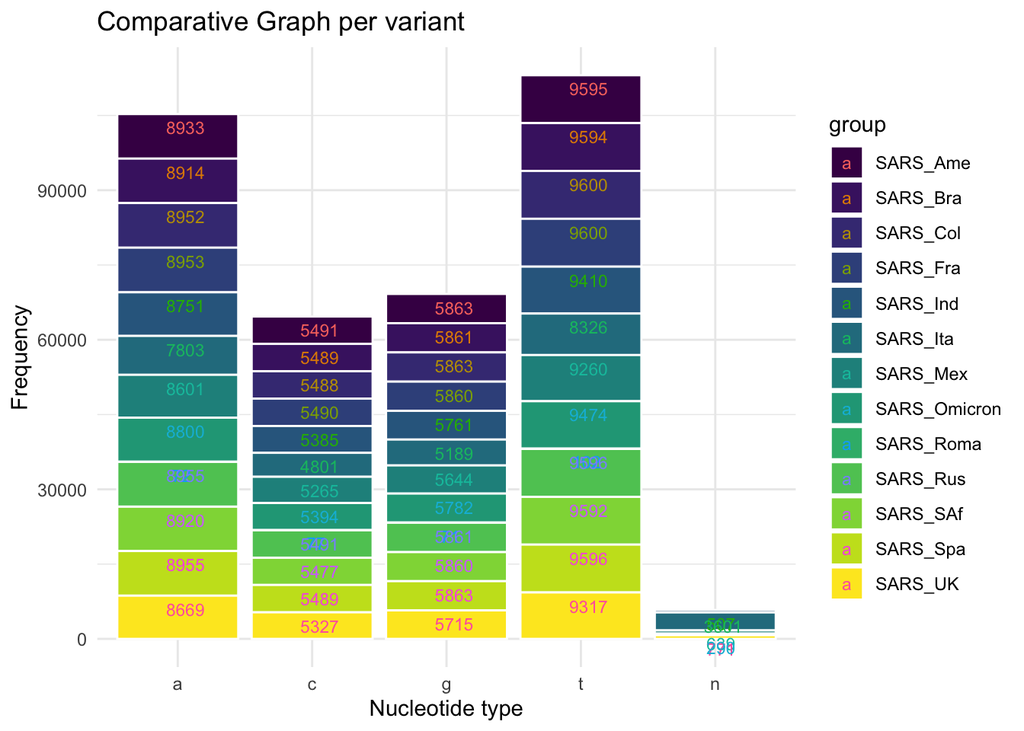

```r
g1 <- ggplot(mm, aes(x,y, col =group,fill = group))
g1 <- g1 + geom_bar(stat = "identity",color = "white") + theme_minimal()
g1 <- g1 + geom_text(aes(label=y),size = 3, position = "stack",vjust= 1.6, hjust = 0.3)
g1 <- g1 + scale_fill_viridis_d()
g1 <- g1 + xlab("Nucleotide type") + ylab("Frequency") + ggtitle("Comparative Graph per variant")
g1
```

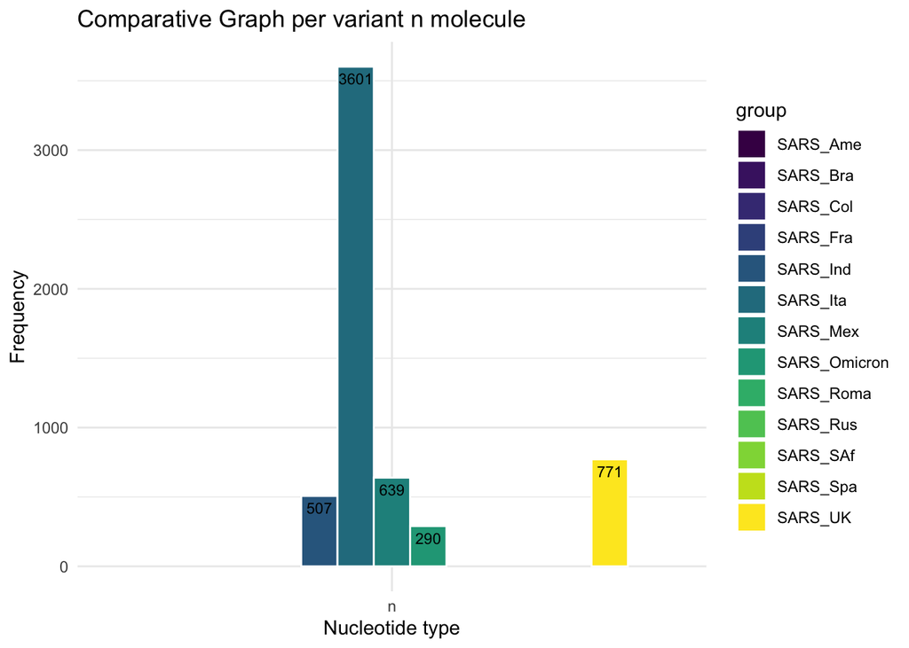

```r
n <- subset(mm, x=="n")
g2 <- ggplot(n, aes(x,y, col = group,fill = group))
g2 <- g2 + geom_bar(stat = "identity",color = "white",position="dodge") + theme_minimal()
g2 <- g2 + geom_text(aes(label=y), position = position_dodge(0.9),vjust= 1.6,color = "black",size = 3)
g2 <- g2 + scale_fill_viridis_d()
g2 <- g2 + xlab("Nucleotide type") + ylab("Frequency") + ggtitle("Comparative Graph per variant n molecule")
g2
```

4. ¿Cuál es el %GC de cada variante?

```r
gc1 <- subset(mm, x==c("g","c"))
gc1
```

```
##    x    y        group
## 2  c 5477     SARS_SAf
## 3  g 5860     SARS_SAf
## 12 c 5489     SARS_Bra
## 13 g 5861     SARS_Bra
## 22 c 5490     SARS_Fra
## 23 g 5860     SARS_Fra
## 32 c 4801     SARS_Ita
## 33 g 5189     SARS_Ita
## 42 c   77    SARS_Roma
## 43 g   71    SARS_Roma
## 52 c 5489     SARS_Spa
## 53 g 5863     SARS_Spa
## 62 c 5394 SARS_Omicron
## 63 g 5782 SARS_Omicron
```

```r
#Porcentaje South Africa
gc1_SAf <- subset(mm, group=="SARS_SAf")
gc1_SAf <- subset(gc1_SAf, x==c("g","c"))
porc_SA <- sum((gc1_SAf$y) * 100) / tamaño(SARS_SAf_fas[[1]])
print("Porcentaje de South Africa: ")
```

```
## [1] "Porcentaje de South Africa: "
```

```r
print(porc_SA)
```

```
## [1] 37.98117
```

```r
#Porcentaje Brazil
gc1_Bra <- subset(mm, group=="SARS_Bra")
gc1_Bra <- subset(gc1_Bra, x==c("g","c"))
porc_Bra <- sum((gc1_Bra$y) * 100) / tamaño(SARS_Bra_fas[[1]])
print("Porcentaje de Brazil: ")
```

```
## [1] "Porcentaje de Brazil: "
```

```r
print(porc_Bra)
```

```
## [1] 38.01326
```

```r
#Porcentaje France
gc1_Fra <- subset(mm, group=="SARS_Fra")
gc1_Fra <- subset(gc1_Fra, x==c("g","c"))
porc_Fra <- sum((gc1_Fra$y) * 100) / tamaño(SARS_Fra_fas[[1]])
print("Porcentaje de France: ")
```

```
## [1] "Porcentaje de France: "
```

```r
print(porc_Fra)
```

```
## [1] 37.95606
```

```r
#Porcentaje de Italia
gc1_Ita <- subset(mm, group=="SARS_Ita")
gc1_Ita <- subset(gc1_Ita, x==c("g","c"))
porc_Ita <- sum((gc1_Ita$y) * 100) / tamaño(SARS_Ita_fas[[1]])
print("Porcentaje de Italy: ")
```

```
## [1] "Porcentaje de Italy: "
```

```r
print(porc_Ita)
```

```
## [1] 33.61373
```

```r
#Porcentaje de Roma
gc1_Roma <- subset(mm, group=="SARS_Roma")
gc1_Roma <- subset(gc1_Roma, x==c("g","c"))
porc_Roma <- sum((gc1_Roma$y) * 100) / tamaño(SARS_Roma_fas[[1]])
print("Porcentaje de Roma: ")
```

```
## [1] "Porcentaje de Roma: "
```

```r
print(porc_Roma)
```

```
## [1] 45.96273
```

5. Crea las secuencias contrasentido de cada variante.

```r
hebra_directa_a_inversa <- function(dna){

  string <- ''
  #for (N in dna) {
    #string<-paste(string,N,sep='')
  #}
  inversa <- rev(strsplit(dna, NULL))
  return(paste(inversa, collapse= ''))
}

print(hebra_directa_a_inversa(SARS_SAf_fas[[1]]))
```

```
## [1] "aaaaaaaaaaaaaaaacagtaagaggattcttcgataattttagtgtacccctatcgtga…"
```

```r
print(hebra_directa_a_inversa(SARS_Ame_fas[[1]]))
```

```
## [1] "aaaaaaaaaaaacagtaagaggattcttcgataattttagtgtacccctatcgtgatgat…"
```

```r
print(hebra_directa_a_inversa(SARS_Bra_fas[[1]]))
```

```
## [1] "aggattcttcgataattttagtgtacccctatcgtgatgattttaattaaaatgtgtaat…"
```

```r
print(hebra_directa_a_inversa(SARS_Col_fas[[1]]))
```

```
## [1] "aaaaaaaaaaaaaaaaaaaaaaaaaaaaaaaaacagtaagaggattcttcgataatttta…"
```

```r
print(hebra_directa_a_inversa(SARS_Fra_fas[[1]]))
```

```
## [1] "aaaaaaaaaaaaaaaaaaaaaaaaaaaaaaaaacagtaagaggattcttcgataatttta…"
```

```r
print(hebra_directa_a_inversa(SARS_Ind_fas[[1]]))
```

```
## [1] "gtgtacccctatcgtgatgattttaattaaaatgtgtaatccngagaaggtatatccgtc…"
```

```r
print(hebra_directa_a_inversa(SARS_Ita_fas[[1]]))
```

```
## [1] "agcatgaggcgcaccggagccacttttacaccaccgagaaagttcaggagggattacaat…"
```

```r
print(hebra_directa_a_inversa(SARS_Mex_fas[[1]]))
```

```
## [1] "gatacactctaatttcaattgatgtagatgaacacgatacatcaatgctcttaagtaaga…"
```

```r
print(hebra_directa_a_inversa(SARS_Peru_fas[[1]]))
```

```
## [1] "caatgtgtgactaatttctaagatacactctaatttcaattgatgtagatgaacacgata…"
```

```r
print(hebra_directa_a_inversa(SARS_Roma_fas[[1]]))
```

```
## [1] "ctaaagaaatccgtccaggaactacagtgtcgcaggatctaccacaggtcgttatgcttc…"
```

```r
print(hebra_directa_a_inversa(SARS_Rus_fas[[1]]))
```

```
## [1] "aaaaaaaaaaaaaaaaaaaaaaaaaaaaaaaaacagtaagaggattcttcgataatttta…"
```

```r
print(hebra_directa_a_inversa(SARS_Spa_fas[[1]]))
```

```
## [1] "aaaaaaaaaaaaaaaaaaaaaaaaaaaaaaaaacagtaagaggattcttcgataatttta…"
```

```r
print(hebra_directa_a_inversa(SARS_UK_fas[[1]]))
```

```
## [1] "attttagtgtacccctatcgtgatgattttaattaaaatgtgtaatcccgagaaggtata…"
```

```r
print(hebra_directa_a_inversa(SARS_Omicron_fas[[1]]))
```

```
## [1] "tgattttaattaaaatgtgtaatcccgagaaggtatatccgtcgagagggatcgtaacaa…"
```